# Introduction to Natural Language Processing (NLP)

- Rémy Frenoy
- https://www.linkedin.com/in/rfrenoy/
- https://github.com/rfrenoy
- https://github.com/rfrenoy/essec_nlp_course

# Disclaimer

- Lot of content in a little time
- Focus on main ideas, lot of links to best resources I know if you want to discover more.
- All content is available, at the end I'll show you how to run the code on your laptops
- Inspired from [Kaggle intro course on NLP](https://www.kaggle.com/learn/natural-language-processing) and [PyTorch tutorials on NLP](https://pytorch.org/tutorials/intermediate/char_rnn_classification_tutorial.html)

# Why is NLP an important Topic?

- Close relationship between language and knowledge
- Historical domain for AI (Turing test)
- Most data is textual
- Data is knowledge, data is textual, knowledge is power, so understanding text is... power

# NLP and machine learning

## What's machine learning?

Tom Mitchell: *"A computer program is said to learn from experience E with respect to some class of tasks T and performance measure P if its performance at tasks in T, as measured by P, improves with experience E"*

- Experience E -> new data
- Class of task T -> Classification, generation, translation, ...
- Performance P -> How good the model is at doing T

The big difference between machine learning and "classical" programming is the fact that *we cannot explicitely program the rules* (it wouldn't evolve with experience *E*). So how do we find the rules?

Instead of computing a result based on a set of predefined criteria, let's say "if the flat is located in the 5th arrondissement of Paris, then its value per square meter is 13000 euros", we will construct some *"vector of criteria"* and some *"vector of weights"*, and our output will be the inner product of the two.

We will **optimize** the choice of values for our vector of weights to *minimize some cost function*, generally using [gradient descent](https://youtu.be/AeRwohPuUHQ).

## An example of regression

|  | arrondissement | floor | max floor in building | price per meter square |
| --- | --- | --- | --- | --- |
| 0 | 17 | 7 | 7 | 11000 |
| 1 | 5 | 1 | 7 | 10000 |
| 2 | 3 | 4 | 4 | 13000 |
| 3 | 20 | 2 | 3 | 9500 |
| 4 | 19 | 11 | 20 | 8700 |
| 5 | 17 | 1 | 6 | 8000 |

Our model will try to find the price from the three first kinds of information. We can express our loss as some kind of difference between the predicted price and the real price, choose the loss function wisely so as to be able to compute gradient descent on it.

## What about now?

|  | id | text | is real disaster? |
| --- | --- | --- | --- |
| 0 | 1 | Our Deeds are the Reason of this #earthquake May ALLAH Forgive us all | 1 |
| 1 | 4 | Forest fire near La Ronge Sask. Canada | 1 |
| 2 | 5 | All residents asked to 'shelter in place' are being notified by officers. No other evacuation or shelter in place orders are expected | 1 |
| 3 | 6 | 13,000 people receive #wildfires evacuation orders in California | 1 |
| 4 | 7 | Just got sent this photo from Ruby #Alaska as smoke from #wildfires pours into a school | 1 |

# Data Preparation

NLP may be the domain where data preparation has the biggest impact on performance. Choices made during this phase can make the difference between a bad, a good and an excellent model.

**Choices made during data preparation depends on the context studied.**

*Example: It is usually good practice to standardize the text and put everything in lower or upper case. But if you are trying to classify toxic comments, case carry signal, and this phase of standardization will lower your final model performances.*

## Extracting data and format it with regular expression

```python
import pandas as pd
fake_operation_data = pd.read_excel('fake_operation_data.xlsx')
```

```python
print(fake_operation_data.to_markdown())
```

```
|    | timestamp           | comment                                                                          |
|---:|:--------------------|:---------------------------------------------------------------------------------|
|  0 | 2020-01-01 00:00:00 | NTR                                                                              |
|  1 | 2020-01-02 00:00:00 | Nothing to report                                                                |
|  2 | 2020-01-03 00:00:00 | - Broke element on machine A, need to repair                                    |
|    |                     | '- Something weird going on on machine D, don't know what, should investigate 😰 |
|    |                     | '- Everything ok on other equipments                                            |
```

```python
def sanitize_comments(raw_df):
    import re
    new_lines = []
    for i, row in raw_df.iterrows():
        # p = re.compile(r"'?\-? ?([\w | |'|,]*)", re.IGNORECASE)
        p = re.compile(r"'?\-? ?(.*)", re.IGNORECASE)
        new_line_comments = [match for match in p.findall(row.comment)
                             if match != '']
        new_lines.append(pd.DataFrame({'timestamp': [row.timestamp] * len(new_line_comments),
                                       'comment': new_line_comments}))
    return pd.concat(new_lines)
```

```python
cleaned_df = sanitize_comments(fake_operation_data)
print(cleaned_df.to_markdown())
```

```
|    | timestamp           | comment                                                                       |
|---:|:--------------------|:------------------------------------------------------------------------------|
|  0 | 2020-01-01 00:00:00 | NTR                                                                           |
|  0 | 2020-01-02 00:00:00 | Nothing to report                                                             |
|  0 | 2020-01-03 00:00:00 | Broke element on machine A, need to repair                                    |
|  1 | 2020-01-03 00:00:00 | Something weird going on on machine D, don't know what, should investigate 😰 |
|  2 | 2020-01-03 00:00:00 | Everything ok on other equipments                                             |
```

A lot of tools exist for you to quickly test your regular expressions, such as https://regex101.com/. The library documentation is available on https://docs.python.org/3/howto/regex.html.

## Tokenisation, lemmatization, stop words, ...

There are a lot of words in a vocabulary, some carrying more meaning than others. The goal of tokenisation is to separate sentences into terms. Lemmatization tries to standardize family of words to their common root to reduce the number of dimensionalities (= making the problem simpler). Stop words remove the words that appear so often that they should not carry differentiating meaning.

**Treat this with care!**

```python
import spacy
nlp = spacy.load('en')
```

```python
text = cleaned_df.comment.iloc[3]
print(text)
print('---')
doc = nlp(text)
for token in doc:
    print(token)
print()
```

```
Something weird going on on machine D, don't know what, should investigate 😰
---
Something
weird
going
on
on
machine
D
,
do
n't
know
what
,
should
investigate
😰
```

```python
text = cleaned_df.comment.iloc[3]
print("{:>10s}\t{:>10s}\t{:>10s}\t{:>10s}".format('Token', 'Lemma', 'Stopword', 'Punctuation'))
print("-"*80)
doc = nlp(text)
for token in doc:
    print("{:>10s}\t{:>10s}\t{:>10s}\t{:>10s}".format(str(token), str(token.lemma_), str(token.is_stop), str(token.is_punct)))
print()
```

```
     Token	     Lemma	  Stopword	Punctuation
--------------------------------------------------------------------------------
 Something	 something	      True	     False
     weird	     weird	     False	     False
     going	        go	     False	     False
        on	        on	      True	     False
        on	        on	      True	     False
   machine	   machine	     False	     False
         D	         d	     False	     False
         ,	         ,	     False	      True
        do	        do	      True	     False
       n't	       not	      True	     False
      know	      know	     False	     False
      what	      what	      True	     False
         ,	         ,	     False	      True
    should	    should	      True	     False
investigate	investigate	     False	     False
         😰	         😰	     False	     False
```

```python
for token in nlp(text):
    if not token.is_stop and not token.is_punct:
        print(token)
```

```
weird
going
machine
D
know
investigate
😰
```

## Emojis

A good example showing that language is a continuously-evolving domain, the use of emojis is now very common. So common that taking into account the meaning of emojis can have a tremendous impact on your model! (It depends on your context again... If you work for Doctrine, you should not see emojis that often ;-) )

```python
import requests
import re

r = requests.get('https://unicode.org/Public/emoji/12.0/emoji-test.txt')
lines = r.text.split('\n')
filtered_lines = [line for line in lines if len(line) > 0 and line[0] != '#']
```

```python
filtered_lines[:5]
```

```
['1F600                                      ; fully-qualified     # 😀 grinning face',
 '1F603                                      ; fully-qualified     # 😃 grinning face with big eyes',
 '1F604                                      ; fully-qualified     # 😄 grinning face with smiling eyes',
 '1F601                                      ; fully-qualified     # 😁 beaming face with smiling eyes',
 '1F606                                      ; fully-qualified     # 😆 grinning squinting face']
```

```python
p = re.compile(".*# ([^\s])* (.*)")
code, meaning = zip(*[p.findall(line)[0] for line in filtered_lines])
```

```python
my_emoji_translator = {c: meaning[i] for i,c in enumerate(code)}
```

```python
my_emoji_translator
```

[output not shown]

[output cut: 946 more lines]

```
 '🖊': 'pen',
 '🖌': 'paintbrush',
 '🖍': 'crayon',
 '📝': 'memo',
 '📁': 'file folder',
 '📂': 'open file folder',
 '🗂': 'card index dividers',
 '📅': 'calendar',
 '📆': 'tear-off calendar',
 '🗒': 'spiral notepad',
 '🗓': 'spiral calendar',
 '📇': 'card index',
 '📈': 'chart increasing',
 '📉': 'chart decreasing',
 ...}
```

```python
text = cleaned_df.comment.iloc[3]
print("{:>10s}\t{:>10s}\t{:>10s}".format('Token', 'Lemma', 'Stopword'))
print("-"*50)
doc = nlp(text)
for token in doc:
    if str(token) in my_emoji_translator:
        emoji_translation = my_emoji_translator[str(token)]
        doc_for_emoji = nlp(emoji_translation)
        for t in doc_for_emoji:
            print("{:>10s}\t{:>10s}\t{:>10s}".format(str(t), str(t.lemma_), str(t.is_stop)))
```

```
     Token	     Lemma	  Stopword
--------------------------------------------------
   anxious	   anxious	     False
      face	      face	     False
      with	      with	      True
     sweat	     sweat	     False
```

```python
print(text)
print('-'*90)
for token in nlp(text):
    if str(token) in my_emoji_translator:
        emoji_translation = my_emoji_translator[str(token)]
        doc_for_emoji = nlp(emoji_translation)
        for t in doc_for_emoji:
            if not t.is_stop and not t.is_punct:
                print(t)
    elif not token.is_stop and not token.is_punct:
        print(token)
```

```
Something weird going on on machine D, don't know what, should investigate 😰
------------------------------------------------------------------------------------------
weird
going
machine
D
know
investigate
anxious
face
sweat
```

# Classification

Classification is one of the most common tasks in machine learning, and the domain of NLP is not an exception. Common classification problems in NLP are sentiment analysis, detection of spam in mail or toxic comments on forums.

More formally, the task of **classification** corresponds to trying to predict **a target that has a finite (countable) number of values.**

## Is our previous data preparation enough to directly train a classifier?

No, we have cleaned the dataset and we now have a dataset with one line per comment, such as this one

```python
!pip install kaggle > /dev/null
```

```python
!kaggle competitions download -c nlp-getting-started
```

```
nlp-getting-started.zip: Skipping, found more recently modified local copy (use --force to force download)
```

```python
!unzip ./nlp-getting-started.zip
```

```
Archive:  ./nlp-getting-started.zip
replace sample_submission.csv? [y]es, [n]o, [A]ll, [N]one, [r]ename: ^C
```

```python
!ls -l ./
```

```
total 4816
-rw-r--r--@ 1 remy.frenoy  staff    9047 Feb 17 17:43 fake_operation_data.xlsx
-rw-r--r--  1 remy.frenoy  staff  607343 Feb 18 13:24 nlp-getting-started.zip
-rw-r--r--  1 remy.frenoy  staff   68756 Feb 18 15:48 nlp_intro.ipynb
-rw-r--r--  1 remy.frenoy  staff  335608 Feb 18 15:40 nlp_intro.slides.html
-rw-r--r--  1 remy.frenoy  staff   22746 Dec 16 20:36 sample_submission.csv
-rw-r--r--  1 remy.frenoy  staff  420783 Dec 16 20:36 test.csv
-rw-r--r--  1 remy.frenoy  staff  987712 Dec 16 20:36 train.csv
```

```python
import pandas as pd

full_df = pd.read_csv('train.csv')
train_df = full_df.iloc[:-1000]
test_df = full_df.iloc[-1000:]
train_df.head()
```

|  | id | keyword | location | text | target |
| --- | --- | --- | --- | --- | --- |
| 0 | 1 | NaN | NaN | Our Deeds are the Reason of this #earthquake M... | 1 |
| 1 | 4 | NaN | NaN | Forest fire near La Ronge Sask. Canada | 1 |
| 2 | 5 | NaN | NaN | All residents asked to 'shelter in place' are ... | 1 |
| 3 | 6 | NaN | NaN | 13,000 people receive #wildfires evacuation or... | 1 |
| 4 | 7 | NaN | NaN | Just got sent this photo from Ruby #Alaska as ... | 1 |

We said machine learning could be illustrated by learning a vector of weights that will multiply a vector of features. For this to work, our vector of features must contain numerical values. We have to convert our text data to numerical data in some way. The most basic way to do it is to use the **Bag of Words** representation.

In Bag of Words (BoW), we will create a matrix with as many columns as we have words in our vocabulary. Each line in the matrix will represent a text, and we will simply put a binary value indicating whether the text contains a given word or not.

Do you see a limitation with this approach?

- A lot of columns!
- Representation of a text only by the words in it: no representation of the order of the words. *"Tom loves maths"* and *"Maths love Tom"* have the same representation, while the two sentences do not have the same meaning.

Some approaches improve BoW representation but keep the same idea: Term Frequency (TF) and Term Frequency-Inverse Document Frequency (TF-IDF) use floating values instead of binary values, representing the ratio between the number of occurences of the word in the text and the number of occurences of the word in the whole corpus.

Instead of using a column per word, it is possible to use group of words (or group of letters in some contexts). These are called N-grams (N being the cardinality of the group). Mostly bigrams and trigrams are used. It allows for a shallow representation of neighborhood but increase dramatically the number of columns, which is an issue (See the curse of dimensionality)

```python
import spacy

# Create an empty model
nlp = spacy.blank("en")

# Create the TextCategorizer with exclusive classes and "bow" architecture
textcat = nlp.create_pipe(
              "textcat",
              config={
                "exclusive_classes": True,
                "architecture": "bow"})

# Add the TextCategorizer to the empty model
nlp.add_pipe(textcat)
```

```python
# Add labels to text classifier
textcat.add_label('no_disaster')
textcat.add_label('disaster')
```

```
1
```

```python
train_texts = train_df['text'].values
train_labels = [{'cats': {'disaster': label == 1,
                          'no_disaster': label == 0}}
                for label in train_df['target']]
```

```python
train_data = list(zip(train_texts, train_labels))
train_data[:3]
```

```
[('Our Deeds are the Reason of this #earthquake May ALLAH Forgive us all',
  {'cats': {'disaster': True, 'no_disaster': False}}),
 ('Forest fire near La Ronge Sask. Canada',
  {'cats': {'disaster': True, 'no_disaster': False}}),
 ("All residents asked to 'shelter in place' are being notified by officers. No other evacuation or shelter in place orders are expected",
  {'cats': {'disaster': True, 'no_disaster': False}})]
```

```python
import random
from spacy.util import minibatch

random.seed(1)
spacy.util.fix_random_seed(1)
optimizer = nlp.begin_training()

losses = {}
for epoch in range(20):
    random.shuffle(train_data)
    # Create the batch generator with batch size = 8
    batches = minibatch(train_data, size=8)
    # Iterate through minibatches
    for batch in batches:
        # Each batch is a list of (text, label) but we need to
        # send separate lists for texts and labels to update().
        # This is a quick way to split a list of tuples into lists
        texts, labels = zip(*batch)
        nlp.update(texts, labels, sgd=optimizer, losses=losses)
    print(losses)
```

```
{'textcat': 4.75042068969924}
{'textcat': 7.534200280497316}
{'textcat': 9.428553090867354}
{'textcat': 10.817569403530797}
{'textcat': 11.857005193585792}
{'textcat': 12.684824872467289}
{'textcat': 13.348254462805926}
{'textcat': 13.903660962851063}
{'textcat': 14.370522920558642}
{'textcat': 14.761760743025206}
{'textcat': 15.098512723614022}
{'textcat': 15.390464223343656}
{'textcat': 15.644695843835024}
{'textcat': 15.870631646182474}
{'textcat': 16.074076384343968}
{'textcat': 16.262207440632935}
{'textcat': 16.429086710450996}
{'textcat': 16.5857346500268}
{'textcat': 16.729227058711775}
{'textcat': 16.865232349534388}
```

```python
texts = ["Just happened a terrible car crash",
         "I like potatoes",
         "I am eating potatoes in a wild fire"]
docs = [nlp.tokenizer(text) for text in texts]

# Use textcat to get the scores for each doc
textcat = nlp.get_pipe('textcat')
scores, _ = textcat.predict(docs)

print(scores)
```

```
[[0.49625212 0.5037479 ]
 [0.644427   0.35557306]
 [0.6178041  0.3821959 ]]
```

```python
docs = [nlp.tokenizer(text) for text in test_df.text]

# Use textcat to get the scores for each doc
textcat = nlp.get_pipe('textcat')
scores, _ = textcat.predict(docs)

print(scores)
```

```
[[4.9454351e-03 9.9505460e-01]
 [8.1476718e-01 1.8523285e-01]
 [9.9718082e-01 2.8191626e-03]
 ...
 [1.1868637e-01 8.8131356e-01]
 [2.8035771e-03 9.9719644e-01]
 [4.3218108e-05 9.9995673e-01]]
```

```python
import numpy as np
preds = np.argmax(scores, axis=1)
good_preds = preds == test_df.target.values
print(good_preds.sum()/len(preds))
```

```
0.732
```

```python
import numpy as np
import spacy

# Need to load the large model to get the vectors
nlp = spacy.load('en_core_web_lg')
with nlp.disable_pipes():
    train_vectors = np.array([nlp(text).vector for text in train_df.text])
    test_vectors = np.array([nlp(text).vector for text in test_df.text])

print(train_vectors.shape)
print(test_vectors.shape)
```

```
(6613, 300)
(1000, 300)
```

```python
from sklearn.svm import LinearSVC

svc = LinearSVC(random_state=1, dual=False, max_iter=10000)
svc.fit(train_vectors, train_df.target)
print(f"Accuracy: {svc.score(test_vectors, test_df.target) * 100:.3f}%", )
```

```
Accuracy: 79.200%
```

# Generation

Text generation can have a lot of applications:

- Chatbots
- Data to text (meeting summary)
- Joke generators!

[figure not shown]

```python
import torch
import torch.nn as nn

class RNN(nn.Module):
    def __init__(self, input_size, hidden_size, output_size):
        super(RNN, self).__init__()
        self.hidden_size = hidden_size

        self.i2h = nn.Linear(n_categories + input_size + hidden_size, hidden_size)
        self.i2o = nn.Linear(n_categories + input_size + hidden_size, output_size)
        self.o2o = nn.Linear(hidden_size + output_size, output_size)
        self.dropout = nn.Dropout(0.1)
        self.softmax = nn.LogSoftmax(dim=1)

    def forward(self, category, input, hidden):
        input_combined = torch.cat((category, input, hidden), 1)
        hidden = self.i2h(input_combined)
        output = self.i2o(input_combined)
        output_combined = torch.cat((hidden, output), 1)
        output = self.o2o(output_combined)
        output = self.dropout(output)
        output = self.softmax(output)
        return output, hidden

    def initHidden(self):
        return torch.zeros(1, self.hidden_size)
```

```python
criterion = nn.NLLLoss()

learning_rate = 0.0005

def train(category_tensor, input_line_tensor, target_line_tensor):
    target_line_tensor.unsqueeze_(-1)
    hidden = rnn.initHidden()

    rnn.zero_grad()

    loss = 0

    for i in range(input_line_tensor.size(0)):
        output, hidden = rnn(category_tensor, input_line_tensor[i], hidden)
        l = criterion(output, target_line_tensor[i])
        loss += l

    loss.backward()

    for p in rnn.parameters():
        p.data.add_(-learning_rate, p.grad.data)

    return output, loss.item() / input_line_tensor.size(0)
```

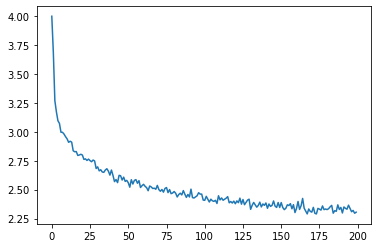

```python
import matplotlib.pyplot as plt
import matplotlib.ticker as ticker

plt.figure()
plt.plot(all_losses)
```

```python
samples('Russian', 'RUS')
```

```
Rovellov
Uarishin
Shallovov
```

```python
samples('German', 'GER')
```

```
Ganter
Erenter
Rone
```

```python
samples('Spanish', 'SPA')
```

```
Santa
Parier
Allan
```

```python
samples('Chinese', 'CHI')
```

```
Chan
Han
Iun
```

```python
samples('French', 'ADG')
```

```
Arter
Deller
Garere
```

# Translation

```python
evaluateRandomly(encoder1, attn_decoder1)
```

```
> nous sommes prets desormais .
= we re ready now .
< we re ready now . <EOS>

> je suis electricien .
= i am an electrician .
< i am an electrician . <EOS>

> tu es plus grand que moi .
= you re taller than i am .
< you re taller than i . <EOS>

> ce sont mes amis .
= they are my friends .
< they re my friends . <EOS>

> vous ne convenez pas .
= you re not fit .
< you re not following . <EOS>

> ce n est pas mon cousin .
= he s not my cousin .
< he s not my my . <EOS>

> je suis ravi de faire votre connaissance .
= i m very pleased to meet you .
< i m pleased to meet you from . <EOS>

> vous etes une personne merveilleuse .
= you re a wonderful guy .
< you re a wonderful guy . <EOS>

> il n est plus tout jeune .
= he s not young anymore .
< he is not young anymore . <EOS>

> il a des ennuis .
= he is in trouble .
< he is in trouble . <EOS>
```

```python
output_words, attentions = evaluate(encoder1, attn_decoder1, 'j ai fini')
' '.join(output_words)
```

```
'i m done . <EOS>'
```

```
input = elle a cinq ans de moins que moi .
output = she is five years younger than me . <EOS>
```

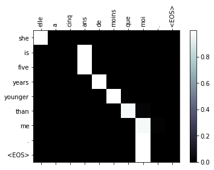

```python
evaluateAndShowAttention("elle a cinq ans de moins que moi .")
```

# Conclusion and take aways

- NLP is a whole domain in the machine learning spectrum
- The domain has its own challenges, mostly around the best way to numerically represent language
- Be careful with the way you handle data, you can easily make performances drop with a single bad choice
- Test your model for potential biases, see [Jigsaw Kaggle competition](https://www.kaggle.com/c/jigsaw-unintended-bias-in-toxicity-classification)